# Risk Factor Analysis

## Outcome Variable

**Outcome Variable:** pers_wasted624

## Predictor Variables

**Intervention Variable:** ever_sstunted06

**Adjustment Set:**

- sex
- arm
- enstunt
- month
- brthmon
- vagbrth
- single
- W_gagebrth
- W_birthwt
- W_birthlen
- W_mage
- W_mhtcm
- W_meducyrs
- W_feducyrs
- W_parity
- delta_month
- delta_brthmon
- delta_vagbrth
- delta_single
- delta_W_gagebrth
- delta_W_birthwt
- delta_W_birthlen
- delta_W_mage
- delta_W_mhtcm
- delta_W_meducyrs
- delta_W_feducyrs
- delta_W_parity

## Stratifying Variables

The analysis was stratified on these variable(s):

- studyid
- country

## Data Summary

| studyid | country | ever_sstunted06 | pers_wasted624 | n_cell | n |
| --- | --- | --- | --- | --- | --- |
| ki0047075b-MAL-ED | BANGLADESH | 0 | 0 | 206 | 240 |
| ki0047075b-MAL-ED | BANGLADESH | 0 | 1 | 16 | 240 |
| ki0047075b-MAL-ED | BANGLADESH | 1 | 0 | 16 | 240 |
| ki0047075b-MAL-ED | BANGLADESH | 1 | 1 | 2 | 240 |
| ki0047075b-MAL-ED | BRAZIL | 0 | 0 | 190 | 207 |
| ki0047075b-MAL-ED | BRAZIL | 0 | 1 | 2 | 207 |
| ki0047075b-MAL-ED | BRAZIL | 1 | 0 | 15 | 207 |
| ki0047075b-MAL-ED | BRAZIL | 1 | 1 | 0 | 207 |
| ki0047075b-MAL-ED | INDIA | 0 | 0 | 194 | 235 |
| ki0047075b-MAL-ED | INDIA | 0 | 1 | 22 | 235 |
| ki0047075b-MAL-ED | INDIA | 1 | 0 | 13 | 235 |
| ki0047075b-MAL-ED | INDIA | 1 | 1 | 6 | 235 |
| ki0047075b-MAL-ED | NEPAL | 0 | 0 | 224 | 235 |
| ki0047075b-MAL-ED | NEPAL | 0 | 1 | 2 | 235 |
| ki0047075b-MAL-ED | NEPAL | 1 | 0 | 9 | 235 |
| ki0047075b-MAL-ED | NEPAL | 1 | 1 | 0 | 235 |
| ki0047075b-MAL-ED | PERU | 0 | 0 | 234 | 270 |
| ki0047075b-MAL-ED | PERU | 0 | 1 | 1 | 270 |
| ki0047075b-MAL-ED | PERU | 1 | 0 | 34 | 270 |
| ki0047075b-MAL-ED | PERU | 1 | 1 | 1 | 270 |
| ki0047075b-MAL-ED | SOUTH AFRICA | 0 | 0 | 230 | 259 |
| ki0047075b-MAL-ED | SOUTH AFRICA | 0 | 1 | 2 | 259 |
| ki0047075b-MAL-ED | SOUTH AFRICA | 1 | 0 | 27 | 259 |
| ki0047075b-MAL-ED | SOUTH AFRICA | 1 | 1 | 0 | 259 |
| ki0047075b-MAL-ED | TANZANIA, UNITED REPUBLIC OF | 0 | 0 | 209 | 245 |
| ki0047075b-MAL-ED | TANZANIA, UNITED REPUBLIC OF | 0 | 1 | 0 | 245 |
| ki0047075b-MAL-ED | TANZANIA, UNITED REPUBLIC OF | 1 | 0 | 36 | 245 |
| ki0047075b-MAL-ED | TANZANIA, UNITED REPUBLIC OF | 1 | 1 | 0 | 245 |
| ki1000108-CMC-V-BCS-2002 | INDIA | 0 | 0 | 260 | 370 |
| ki1000108-CMC-V-BCS-2002 | INDIA | 0 | 1 | 16 | 370 |

[output cut: 102 more lines]

The following strata were considered:

- studyid: ki0047075b-MAL-ED, country: BANGLADESH
- studyid: ki0047075b-MAL-ED, country: BRAZIL
- studyid: ki0047075b-MAL-ED, country: INDIA
- studyid: ki0047075b-MAL-ED, country: NEPAL
- studyid: ki0047075b-MAL-ED, country: PERU
- studyid: ki0047075b-MAL-ED, country: SOUTH AFRICA
- studyid: ki0047075b-MAL-ED, country: TANZANIA, UNITED REPUBLIC OF
- studyid: ki1000108-CMC-V-BCS-2002, country: INDIA
- studyid: ki1000108-IRC, country: INDIA
- studyid: ki1000109-EE, country: PAKISTAN
- studyid: ki1000109-ResPak, country: PAKISTAN
- studyid: ki1000304b-SAS-CompFeed, country: INDIA
- studyid: ki1000304b-SAS-FoodSuppl, country: INDIA
- studyid: ki1017093-NIH-Birth, country: BANGLADESH
- studyid: ki1017093b-PROVIDE, country: BANGLADESH
- studyid: ki1017093c-NIH-Crypto, country: BANGLADESH
- studyid: ki1066203-TanzaniaChild2, country: TANZANIA, UNITED REPUBLIC OF
- studyid: ki1101329-Keneba, country: GAMBIA
- studyid: ki1112895-Guatemala BSC, country: GUATEMALA
- studyid: ki1113344-GMS-Nepal, country: NEPAL
- studyid: ki1114097-CMIN, country: BANGLADESH
- studyid: ki1114097-CMIN, country: BRAZIL
- studyid: ki1114097-CMIN, country: GUINEA-BISSAU
- studyid: ki1114097-CMIN, country: PERU
- studyid: ki1114097-CONTENT, country: PERU
- studyid: ki1119695-PROBIT, country: BELARUS
- studyid: ki1126311-ZVITAMBO, country: ZIMBABWE
- studyid: ki1135781-COHORTS, country: GUATEMALA
- studyid: ki1135781-COHORTS, country: INDIA
- studyid: ki1135781-COHORTS, country: PHILIPPINES
- studyid: ki1148112-LCNI-5, country: MALAWI
- studyid: kiGH5241-JiVitA-3, country: BANGLADESH
- studyid: kiGH5241-JiVitA-4, country: BANGLADESH

### Dropped Strata

Some strata were dropped due to rare outcomes:

- studyid: ki0047075b-MAL-ED, country: BANGLADESH
- studyid: ki0047075b-MAL-ED, country: BRAZIL
- studyid: ki0047075b-MAL-ED, country: NEPAL
- studyid: ki0047075b-MAL-ED, country: PERU
- studyid: ki0047075b-MAL-ED, country: SOUTH AFRICA
- studyid: ki0047075b-MAL-ED, country: TANZANIA, UNITED REPUBLIC OF
- studyid: ki1017093b-PROVIDE, country: BANGLADESH
- studyid: ki1112895-Guatemala BSC, country: GUATEMALA
- studyid: ki1114097-CMIN, country: BRAZIL
- studyid: ki1114097-CMIN, country: PERU
- studyid: ki1114097-CONTENT, country: PERU
- studyid: ki1119695-PROBIT, country: BELARUS
- studyid: ki1148112-LCNI-5, country: MALAWI

## Methods Detail

We’re interested in the causal parameters $E[Y_a]$ for all values of $a \in \mathcal{A}$. These parameters represent the mean outcome if, possibly contrary to fact, we intervened to set all units to have $A=a$. Under the randomization and positivity assumptions, these are identified by the statistical parameters $\psi_a=E_W[E_{Y|A,W}(Y|A=a,W)]$. In addition, we’re interested in the mean of $Y$, $E[Y]$ under no intervention (the observed mean). We will estimate these parameters by using SuperLearner to fit the relevant likelihood factors – $E_{Y|A,W}(Y|A=a,W)$ and $p(A=a|W)$, and then updating our likelihood fit using a joint TMLE.

For unadjusted analyses ($W=\{\}$), initial likelihoods were estimated using Lrnr_glm to estimate the simple $E(Y|A)$ and Lrnr_mean to estimate $p(A)$. For adjusted analyses, a small library containing Lrnr_glmnet, Lrnr_xgboost, and Lrnr_mean was used.

Having estimated these parameters, we will then use the delta method to estimate relative risks and attributable risks relative to a prespecified baseline level of $A$.

# Results Detail

## Results Plots

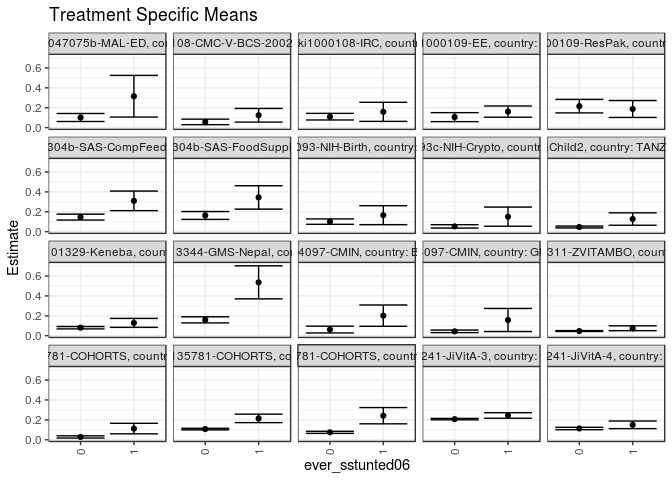

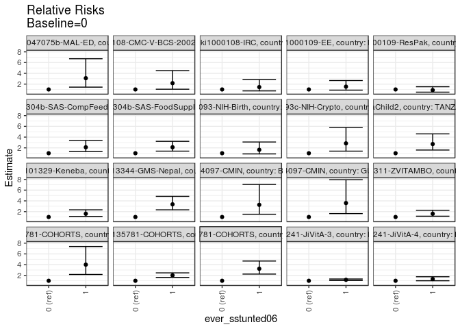

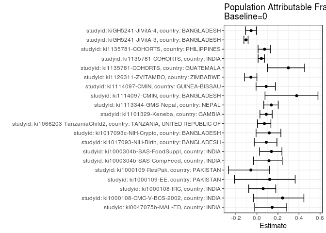

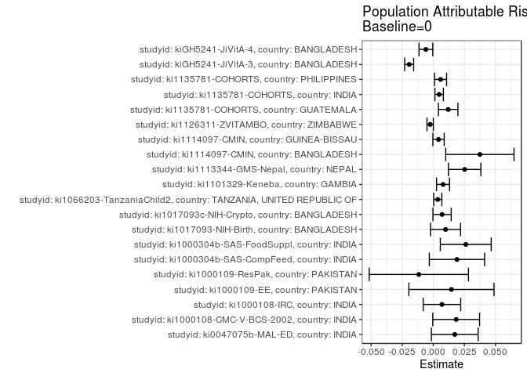

## Results Table

### Parameter: TSM

| studyid | country | intervention_level | baseline_level | estimate | ci_lower | ci_upper |
| --- | --- | --- | --- | --- | --- | --- |
| ki0047075b-MAL-ED | INDIA | 0 | NA | 0.1018519 | 0.0614310 | 0.1422727 |
| ki0047075b-MAL-ED | INDIA | 1 | NA | 0.3157895 | 0.1063343 | 0.5252446 |
| ki1000108-CMC-V-BCS-2002 | INDIA | 0 | NA | 0.0572337 | 0.0295840 | 0.0848835 |
| ki1000108-CMC-V-BCS-2002 | INDIA | 1 | NA | 0.1241840 | 0.0557890 | 0.1925790 |
| ki1000108-IRC | INDIA | 0 | NA | 0.1100742 | 0.0769251 | 0.1432232 |
| ki1000108-IRC | INDIA | 1 | NA | 0.1588284 | 0.0630926 | 0.2545642 |
| ki1000109-EE | PAKISTAN | 0 | NA | 0.1057039 | 0.0604950 | 0.1509127 |
| ki1000109-EE | PAKISTAN | 1 | NA | 0.1611474 | 0.1046586 | 0.2176363 |
| ki1000109-ResPak | PAKISTAN | 0 | NA | 0.2159588 | 0.1480967 | 0.2838208 |
| ki1000109-ResPak | PAKISTAN | 1 | NA | 0.1875446 | 0.1025416 | 0.2725475 |
| ki1000304b-SAS-CompFeed | INDIA | 0 | NA | 0.1466492 | 0.1169377 | 0.1763606 |
| ki1000304b-SAS-CompFeed | INDIA | 1 | NA | 0.3097582 | 0.2113561 | 0.4081604 |
| ki1000304b-SAS-FoodSuppl | INDIA | 0 | NA | 0.1629050 | 0.1233303 | 0.2024796 |
| ki1000304b-SAS-FoodSuppl | INDIA | 1 | NA | 0.3442698 | 0.2266309 | 0.4619088 |
| ki1017093-NIH-Birth | BANGLADESH | 0 | NA | 0.1010348 | 0.0738900 | 0.1281795 |
| ki1017093-NIH-Birth | BANGLADESH | 1 | NA | 0.1657163 | 0.0705223 | 0.2609102 |
| ki1017093c-NIH-Crypto | BANGLADESH | 0 | NA | 0.0531758 | 0.0362619 | 0.0700896 |
| ki1017093c-NIH-Crypto | BANGLADESH | 1 | NA | 0.1509434 | 0.0544976 | 0.2473892 |
| ki1066203-TanzaniaChild2 | TANZANIA, UNITED REPUBLIC OF | 0 | NA | 0.0469331 | 0.0374645 | 0.0564016 |
| ki1066203-TanzaniaChild2 | TANZANIA, UNITED REPUBLIC OF | 1 | NA | 0.1271213 | 0.0647749 | 0.1894677 |
| ki1101329-Keneba | GAMBIA | 0 | NA | 0.0804325 | 0.0685896 | 0.0922753 |
| ki1101329-Keneba | GAMBIA | 1 | NA | 0.1290742 | 0.0841972 | 0.1739513 |
| ki1113344-GMS-Nepal | NEPAL | 0 | NA | 0.1594924 | 0.1287722 | 0.1902126 |
| ki1113344-GMS-Nepal | NEPAL | 1 | NA | 0.5367421 | 0.3704845 | 0.7029997 |
| ki1114097-CMIN | BANGLADESH | 0 | NA | 0.0617159 | 0.0274474 | 0.0959843 |
| ki1114097-CMIN | BANGLADESH | 1 | NA | 0.2016202 | 0.0943846 | 0.3088557 |
| ki1114097-CMIN | GUINEA-BISSAU | 0 | NA | 0.0439224 | 0.0310796 | 0.0567652 |
| ki1114097-CMIN | GUINEA-BISSAU | 1 | NA | 0.1578947 | 0.0419004 | 0.2738891 |
| ki1126311-ZVITAMBO | ZIMBABWE | 0 | NA | 0.0467964 | 0.0423331 | 0.0512597 |
| ki1126311-ZVITAMBO | ZIMBABWE | 1 | NA | 0.0749817 | 0.0506377 | 0.0993258 |
| ki1135781-COHORTS | GUATEMALA | 0 | NA | 0.0280869 | 0.0170340 | 0.0391398 |
| ki1135781-COHORTS | GUATEMALA | 1 | NA | 0.1123473 | 0.0594541 | 0.1652404 |
| ki1135781-COHORTS | INDIA | 0 | NA | 0.1071126 | 0.0993509 | 0.1148742 |
| ki1135781-COHORTS | INDIA | 1 | NA | 0.2145953 | 0.1720029 | 0.2571877 |
| ki1135781-COHORTS | PHILIPPINES | 0 | NA | 0.0745974 | 0.0641629 | 0.0850319 |
| ki1135781-COHORTS | PHILIPPINES | 1 | NA | 0.2416460 | 0.1598607 | 0.3234313 |
| kiGH5241-JiVitA-3 | BANGLADESH | 0 | NA | 0.2071561 | 0.2001266 | 0.2141857 |
| kiGH5241-JiVitA-3 | BANGLADESH | 1 | NA | 0.2442005 | 0.2162694 | 0.2721316 |
| kiGH5241-JiVitA-4 | BANGLADESH | 0 | NA | 0.1131977 | 0.1011530 | 0.1252423 |
| kiGH5241-JiVitA-4 | BANGLADESH | 1 | NA | 0.1499219 | 0.1118411 | 0.1880028 |

### Parameter: E(Y)

| studyid | country | intervention_level | baseline_level | estimate | ci_lower | ci_upper |
| --- | --- | --- | --- | --- | --- | --- |
| ki0047075b-MAL-ED | INDIA | NA | NA | 0.1191489 | 0.0776405 | 0.1606574 |
| ki1000108-CMC-V-BCS-2002 | INDIA | NA | NA | 0.0756757 | 0.0486905 | 0.1026609 |
| ki1000108-IRC | INDIA | NA | NA | 0.1170732 | 0.0859146 | 0.1482317 |
| ki1000109-EE | PAKISTAN | NA | NA | 0.1203209 | 0.0873047 | 0.1533370 |
| ki1000109-ResPak | PAKISTAN | NA | NA | 0.2043478 | 0.1521230 | 0.2565727 |
| ki1000304b-SAS-CompFeed | INDIA | NA | NA | 0.1657061 | 0.1471754 | 0.1842367 |
| ki1000304b-SAS-FoodSuppl | INDIA | NA | NA | 0.1890547 | 0.1507312 | 0.2273783 |
| ki1017093-NIH-Birth | BANGLADESH | NA | NA | 0.1109057 | 0.0844206 | 0.1373909 |
| ki1017093c-NIH-Crypto | BANGLADESH | NA | NA | 0.0602740 | 0.0429977 | 0.0775502 |
| ki1066203-TanzaniaChild2 | TANZANIA, UNITED REPUBLIC OF | NA | NA | 0.0505451 | 0.0409848 | 0.0601054 |
| ki1101329-Keneba | GAMBIA | NA | NA | 0.0882993 | 0.0766987 | 0.0998998 |
| ki1113344-GMS-Nepal | NEPAL | NA | NA | 0.1847458 | 0.1534039 | 0.2160876 |
| ki1114097-CMIN | BANGLADESH | NA | NA | 0.0992063 | 0.0622241 | 0.1361886 |
| ki1114097-CMIN | GUINEA-BISSAU | NA | NA | 0.0481809 | 0.0350130 | 0.0613488 |
| ki1126311-ZVITAMBO | ZIMBABWE | NA | NA | 0.0442925 | 0.0403901 | 0.0481949 |
| ki1135781-COHORTS | GUATEMALA | NA | NA | 0.0400782 | 0.0280529 | 0.0521035 |
| ki1135781-COHORTS | INDIA | NA | NA | 0.1118526 | 0.1044114 | 0.1192938 |
| ki1135781-COHORTS | PHILIPPINES | NA | NA | 0.0804557 | 0.0703953 | 0.0905161 |
| kiGH5241-JiVitA-3 | BANGLADESH | NA | NA | 0.1877787 | 0.1812440 | 0.1943134 |
| kiGH5241-JiVitA-4 | BANGLADESH | NA | NA | 0.1072855 | 0.0967458 | 0.1178252 |

### Parameter: RR

| studyid | country | intervention_level | baseline_level | estimate | ci_lower | ci_upper |
| --- | --- | --- | --- | --- | --- | --- |
| ki0047075b-MAL-ED | INDIA | 0 | 0 | 1.0000000 | 1.0000000 | 1.000000 |
| ki0047075b-MAL-ED | INDIA | 1 | 0 | 3.1004784 | 1.4313529 | 6.716000 |
| ki1000108-CMC-V-BCS-2002 | INDIA | 0 | 0 | 1.0000000 | 1.0000000 | 1.000000 |
| ki1000108-CMC-V-BCS-2002 | INDIA | 1 | 0 | 2.1697694 | 1.0434624 | 4.511806 |
| ki1000108-IRC | INDIA | 0 | 0 | 1.0000000 | 1.0000000 | 1.000000 |
| ki1000108-IRC | INDIA | 1 | 0 | 1.4429219 | 0.7345678 | 2.834352 |
| ki1000109-EE | PAKISTAN | 0 | 0 | 1.0000000 | 1.0000000 | 1.000000 |
| ki1000109-EE | PAKISTAN | 1 | 0 | 1.5245177 | 0.8744199 | 2.657938 |
| ki1000109-ResPak | PAKISTAN | 0 | 0 | 1.0000000 | 1.0000000 | 1.000000 |
| ki1000109-ResPak | PAKISTAN | 1 | 0 | 0.8684276 | 0.4996308 | 1.509448 |
| ki1000304b-SAS-CompFeed | INDIA | 0 | 0 | 1.0000000 | 1.0000000 | 1.000000 |
| ki1000304b-SAS-CompFeed | INDIA | 1 | 0 | 2.1122402 | 1.3170055 | 3.387654 |
| ki1000304b-SAS-FoodSuppl | INDIA | 0 | 0 | 1.0000000 | 1.0000000 | 1.000000 |
| ki1000304b-SAS-FoodSuppl | INDIA | 1 | 0 | 2.1133169 | 1.3882547 | 3.217067 |
| ki1017093-NIH-Birth | BANGLADESH | 0 | 0 | 1.0000000 | 1.0000000 | 1.000000 |
| ki1017093-NIH-Birth | BANGLADESH | 1 | 0 | 1.6401903 | 0.8696925 | 3.093305 |
| ki1017093c-NIH-Crypto | BANGLADESH | 0 | 0 | 1.0000000 | 1.0000000 | 1.000000 |
| ki1017093c-NIH-Crypto | BANGLADESH | 1 | 0 | 2.8385744 | 1.3903512 | 5.795302 |
| ki1066203-TanzaniaChild2 | TANZANIA, UNITED REPUBLIC OF | 0 | 0 | 1.0000000 | 1.0000000 | 1.000000 |
| ki1066203-TanzaniaChild2 | TANZANIA, UNITED REPUBLIC OF | 1 | 0 | 2.7085647 | 1.5928501 | 4.605784 |
| ki1101329-Keneba | GAMBIA | 0 | 0 | 1.0000000 | 1.0000000 | 1.000000 |
| ki1101329-Keneba | GAMBIA | 1 | 0 | 1.6047529 | 1.1004093 | 2.340249 |
| ki1113344-GMS-Nepal | NEPAL | 0 | 0 | 1.0000000 | 1.0000000 | 1.000000 |
| ki1113344-GMS-Nepal | NEPAL | 1 | 0 | 3.3653154 | 2.3381470 | 4.843728 |
| ki1114097-CMIN | BANGLADESH | 0 | 0 | 1.0000000 | 1.0000000 | 1.000000 |
| ki1114097-CMIN | BANGLADESH | 1 | 0 | 3.2669091 | 1.5125520 | 7.056085 |
| ki1114097-CMIN | GUINEA-BISSAU | 0 | 0 | 1.0000000 | 1.0000000 | 1.000000 |
| ki1114097-CMIN | GUINEA-BISSAU | 1 | 0 | 3.5948591 | 1.6303945 | 7.926310 |
| ki1126311-ZVITAMBO | ZIMBABWE | 0 | 0 | 1.0000000 | 1.0000000 | 1.000000 |
| ki1126311-ZVITAMBO | ZIMBABWE | 1 | 0 | 1.6022981 | 1.1424903 | 2.247161 |
| ki1135781-COHORTS | GUATEMALA | 0 | 0 | 1.0000000 | 1.0000000 | 1.000000 |
| ki1135781-COHORTS | GUATEMALA | 1 | 0 | 3.9999905 | 2.1694376 | 7.375148 |
| ki1135781-COHORTS | INDIA | 0 | 0 | 1.0000000 | 1.0000000 | 1.000000 |
| ki1135781-COHORTS | INDIA | 1 | 0 | 2.0034560 | 1.6236230 | 2.472148 |
| ki1135781-COHORTS | PHILIPPINES | 0 | 0 | 1.0000000 | 1.0000000 | 1.000000 |
| ki1135781-COHORTS | PHILIPPINES | 1 | 0 | 3.2393366 | 2.2450781 | 4.673914 |
| kiGH5241-JiVitA-3 | BANGLADESH | 0 | 0 | 1.0000000 | 1.0000000 | 1.000000 |
| kiGH5241-JiVitA-3 | BANGLADESH | 1 | 0 | 1.1788235 | 1.0468091 | 1.327486 |
| kiGH5241-JiVitA-4 | BANGLADESH | 0 | 0 | 1.0000000 | 1.0000000 | 1.000000 |
| kiGH5241-JiVitA-4 | BANGLADESH | 1 | 0 | 1.3244261 | 1.0046687 | 1.745953 |

### Parameter: PAR

| studyid | country | intervention_level | baseline_level | estimate | ci_lower | ci_upper |
| --- | --- | --- | --- | --- | --- | --- |
| ki0047075b-MAL-ED | INDIA | 0 | NA | 0.0172971 | -0.0014992 | 0.0360934 |
| ki1000108-CMC-V-BCS-2002 | INDIA | 0 | NA | 0.0184419 | -0.0003729 | 0.0372568 |
| ki1000108-IRC | INDIA | 0 | NA | 0.0069990 | -0.0080931 | 0.0220912 |
| ki1000109-EE | PAKISTAN | 0 | NA | 0.0146170 | -0.0196393 | 0.0488733 |
| ki1000109-ResPak | PAKISTAN | 0 | NA | -0.0116109 | -0.0515398 | 0.0283179 |
| ki1000304b-SAS-CompFeed | INDIA | 0 | NA | 0.0190569 | -0.0031615 | 0.0412753 |
| ki1000304b-SAS-FoodSuppl | INDIA | 0 | NA | 0.0261498 | 0.0056834 | 0.0466161 |
| ki1017093-NIH-Birth | BANGLADESH | 0 | NA | 0.0098710 | -0.0022133 | 0.0219553 |
| ki1017093c-NIH-Crypto | BANGLADESH | 0 | NA | 0.0070982 | -0.0002455 | 0.0144419 |
| ki1066203-TanzaniaChild2 | TANZANIA, UNITED REPUBLIC OF | 0 | NA | 0.0036120 | 0.0003259 | 0.0068981 |
| ki1101329-Keneba | GAMBIA | 0 | NA | 0.0078668 | 0.0026323 | 0.0131012 |
| ki1113344-GMS-Nepal | NEPAL | 0 | NA | 0.0252534 | 0.0121879 | 0.0383189 |
| ki1114097-CMIN | BANGLADESH | 0 | NA | 0.0374905 | 0.0100201 | 0.0649609 |
| ki1114097-CMIN | GUINEA-BISSAU | 0 | NA | 0.0042586 | -0.0003001 | 0.0088172 |
| ki1126311-ZVITAMBO | ZIMBABWE | 0 | NA | -0.0025038 | -0.0050501 | 0.0000424 |
| ki1135781-COHORTS | GUATEMALA | 0 | NA | 0.0119913 | 0.0041490 | 0.0198336 |
| ki1135781-COHORTS | INDIA | 0 | NA | 0.0047400 | 0.0013327 | 0.0081474 |
| ki1135781-COHORTS | PHILIPPINES | 0 | NA | 0.0058583 | 0.0009973 | 0.0107193 |
| kiGH5241-JiVitA-3 | BANGLADESH | 0 | NA | -0.0193774 | -0.0229790 | -0.0157758 |
| kiGH5241-JiVitA-4 | BANGLADESH | 0 | NA | -0.0059121 | -0.0114510 | -0.0003732 |

### Parameter: PAF

| studyid | country | intervention_level | baseline_level | estimate | ci_lower | ci_upper |
| --- | --- | --- | --- | --- | --- | --- |
| ki0047075b-MAL-ED | INDIA | 0 | NA | 0.1451720 | -0.0204566 | 0.2839176 |
| ki1000108-CMC-V-BCS-2002 | INDIA | 0 | NA | 0.2436971 | -0.0337090 | 0.4466585 |
| ki1000108-IRC | INDIA | 0 | NA | 0.0597833 | -0.0775728 | 0.1796308 |
| ki1000109-EE | PAKISTAN | 0 | NA | 0.1214833 | -0.2129921 | 0.3637291 |
| ki1000109-ResPak | PAKISTAN | 0 | NA | -0.0568195 | -0.2709073 | 0.1212046 |
| ki1000304b-SAS-CompFeed | INDIA | 0 | NA | 0.1150042 | -0.0313116 | 0.2405617 |
| ki1000304b-SAS-FoodSuppl | INDIA | 0 | NA | 0.1383184 | 0.0253854 | 0.2381654 |
| ki1017093-NIH-Birth | BANGLADESH | 0 | NA | 0.0890032 | -0.0249244 | 0.1902668 |
| ki1017093c-NIH-Crypto | BANGLADESH | 0 | NA | 0.1177655 | -0.0080550 | 0.2278818 |
| ki1066203-TanzaniaChild2 | TANZANIA, UNITED REPUBLIC OF | 0 | NA | 0.0714613 | 0.0055180 | 0.1330320 |
| ki1101329-Keneba | GAMBIA | 0 | NA | 0.0890923 | 0.0288482 | 0.1455993 |
| ki1113344-GMS-Nepal | NEPAL | 0 | NA | 0.1366927 | 0.0653317 | 0.2026054 |
| ki1114097-CMIN | BANGLADESH | 0 | NA | 0.3779040 | 0.0773619 | 0.5805468 |
| ki1114097-CMIN | GUINEA-BISSAU | 0 | NA | 0.0883867 | -0.0081653 | 0.1756920 |
| ki1126311-ZVITAMBO | ZIMBABWE | 0 | NA | -0.0565296 | -0.1163073 | 0.0000469 |
| ki1135781-COHORTS | GUATEMALA | 0 | NA | 0.2991980 | 0.1000911 | 0.4542521 |
| ki1135781-COHORTS | INDIA | 0 | NA | 0.0423776 | 0.0116777 | 0.0721239 |
| ki1135781-COHORTS | PHILIPPINES | 0 | NA | 0.0728140 | 0.0112428 | 0.1305512 |
| kiGH5241-JiVitA-3 | BANGLADESH | 0 | NA | -0.1031927 | -0.1233517 | -0.0833954 |
| kiGH5241-JiVitA-4 | BANGLADESH | 0 | NA | -0.0551066 | -0.1081551 | -0.0045977 |